# Home Credit Default Risk: Comprehensive EDA Report

**Generated by Antigravity Agent**

## 0. Goal & Constraints

**Goal**: Generate a reproducible, structured, and visual EDA report for the Home Credit Default Risk dataset (`application_train.csv`). **Focus**: Data Quality, Target Distribution, Missingness, Numerical/Categorical distributions, Correlations, and Bias signals. **Constraints**: No missing value imputation, no outlier removal (report only).

```python
import pandas as pd
import numpy as np
import matplotlib.pyplot as plt
import seaborn as sns
from scipy import stats
from sklearn.metrics import roc_auc_score, mutual_info_score
import os
import warnings
import json

# Configuration
warnings.filterwarnings('ignore')
sns.set_style("whitegrid")
plt.rcParams['figure.figsize'] = (12, 6)
pd.set_option('display.max_columns', 100)
pd.set_option('display.max_rows', 50)

# Constants
RANDOM_SEED = 42
TRAIN_PATH = 'application_train.csv'
TEST_PATH = 'application_test.csv'
TARGET_COL = 'TARGET'
ID_COL = 'SK_ID_CURR'

# Output directories
os.makedirs('figures', exist_ok=True)
os.makedirs('tables', exist_ok=True)

print("Environment setup complete.")
```

```
Environment setup complete.
```

```python
def save_figure(fig, filename):
    fig.savefig(f'figures/{filename}', bbox_inches='tight')
    # plt.close(fig) # Keep open for notebook display

def save_table(df, filename):
    df.to_csv(f'tables/{filename}')
    print(f"Saved table: tables/{filename}")

def plot_distribution(df, col, target_col=TARGET_COL, sample_size=50000):
    fig, axes = plt.subplots(1, 2, figsize=(16, 5))

    # Sampling for plotting to improve performance
    plot_df = df.sample(min(len(df), sample_size), random_state=RANDOM_SEED) if len(df) > sample_size else df

    # Distribution
    sns.histplot(data=plot_df, x=col, kde=True, ax=axes[0], color='skyblue')
    axes[0].set_title(f'Distribution of {col}')

    # Relation with Target
    if df[col].dtype == 'object' or len(df[col].unique()) < 20:
        # Categorical or low cardinality
        sns.barplot(data=plot_df, x=col, y=target_col, ax=axes[1], errorbar=('ci', 95))
        axes[1].tick_params(axis='x', rotation=45)
    else:
        # Numerical
        sns.boxplot(data=plot_df, x=target_col, y=col, ax=axes[1])

    axes[1].set_title(f'{col} vs {target_col}')
    plt.tight_layout()
    return fig

def calc_psi(expected, actual, buckettype='bins', buckets=10, axis=0):
    '''Calculate the PSI (Population Stability Index) for two vectors'''
    def scale_range (input, min, max):
        input += -(np.min(input))
        input /= np.max(input) / (max - min)
        input += min
        return input

    breakpoints = np.arange(0, buckets + 1) / (buckets) * 100

    if buckettype == 'bins':
        breakpoints = scale_range(breakpoints, np.min(expected), np.max(expected))
    elif buckettype == 'quantiles':
        breakpoints = np.stack([np.percentile(expected, b) for b in breakpoints])

    expected_percents = np.histogram(expected, breakpoints)[0] / len(expected)
    actual_percents = np.histogram(actual, breakpoints)[0] / len(actual)

    def sub_psi(e_perc, a_perc):
        if a_perc == 0: a_perc = 0.0001
        if e_perc == 0: e_perc = 0.0001
        value = (e_perc - a_perc) * np.log(e_perc / a_perc)
        return(value)

    psi_value = np.sum(sub_psi(expected_percents[i], actual_percents[i]) for i in range(0, len(expected_percents)))
    return psi_value
```

## Chapter A: Data Loading & Meta Info

- **Goal**: Load data, check basic properties (shape, memory, duplicates), and generate a schema summary.

```python
# Load Data
if os.path.exists(TRAIN_PATH):
    df_train = pd.read_csv(TRAIN_PATH)
    print(f"Loaded {TRAIN_PATH}: {df_train.shape}")
else:
    raise FileNotFoundError(f"{TRAIN_PATH} not found. Please ensure the file is in the working directory.")

# Basic Meta Info
memory_usage = df_train.memory_usage(deep=True).sum() / 1024**2
print(f"Memory Usage: {memory_usage:.2f} MB")

# Check ID Uniqueness
n_unique_ids = df_train[ID_COL].nunique()
n_rows = len(df_train)
print(f"Unique IDs: {n_unique_ids}")
print(f"Duplicate IDs: {n_rows - n_unique_ids}")

# Schema Table
schema_d = []
for col in df_train.columns:
    n_unique = df_train[col].nunique()
    n_missing = df_train[col].isnull().sum()
    example_vals = df_train[col].dropna().unique()[:3] if n_unique > 0 else []

    inferred_type = 'numeric'
    if df_train[col].dtype == 'object':
        inferred_type = 'categorical'
    elif 'DAYS' in col or 'DATE' in col:  # Rough heuristic
        inferred_type = 'date-like'

    schema_d.append({
        'col_name': col,
        'dtype': df_train[col].dtype,
        'n_unique': n_unique,
        'pct_unique': n_unique / n_rows,
        'n_missing': n_missing,
        'pct_missing': n_missing / n_rows,
        'example_values': str(list(example_vals)),
        'inferred_type': inferred_type
    })

df_schema = pd.DataFrame(schema_d)
save_table(df_schema, 'schema_table.csv')
display(df_schema.head())
```

```
Loaded application_train.csv: (307511, 122)
Memory Usage: 536.69 MB
Unique IDs: 307511
Duplicate IDs: 0
Saved table: tables/schema_table.csv
```

|  | col_name | dtype | n_unique | pct_unique | n_missing | pct_missing | example_values | inferred_type |
| --- | --- | --- | --- | --- | --- | --- | --- | --- |
| 0 | SK_ID_CURR | int64 | 307511 | 1.000000 | 0 | 0.0 | [100002, 100003, 100004] | numeric |
| 1 | TARGET | int64 | 2 | 0.000007 | 0 | 0.0 | [1, 0] | numeric |
| 2 | NAME_CONTRACT_TYPE | object | 2 | 0.000007 | 0 | 0.0 | ['Cash loans', 'Revolving loans'] | categorical |
| 3 | CODE_GENDER | object | 3 | 0.000010 | 0 | 0.0 | ['M', 'F', 'XNA'] | categorical |
| 4 | FLAG_OWN_CAR | object | 2 | 0.000007 | 0 | 0.0 | ['N', 'Y'] | categorical |

## Chapter B: Target Variable Overview

- **Goal**: Analyze the distribution and imbalance of the target variable.

```
Target Distribution:
TARGET
0    282686
1     24825
Name: count, dtype: int64

Target Percentage:
TARGET
0    0.919271
1    0.080729
Name: proportion, dtype: float64
```

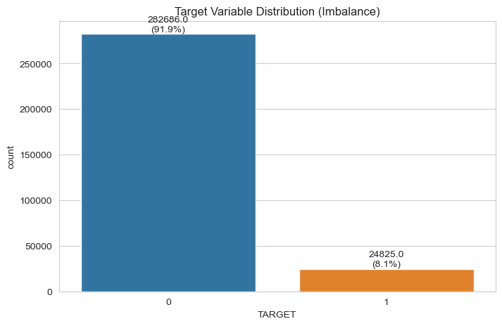

```
Majority Class Baseline Accuracy: 0.9193
Positive Class Prevalence: 0.0807
```

```python
# Target Distribution
target_counts = df_train[TARGET_COL].value_counts()
target_pct = df_train[TARGET_COL].value_counts(normalize=True)

print("Target Distribution:")
print(target_counts)
print("\nTarget Percentage:")
print(target_pct)

# Plot
plt.figure(figsize=(8, 5))
ax = sns.countplot(x=TARGET_COL, data=df_train)
plt.title('Target Variable Distribution (Imbalance)')
for p in ax.patches:
    ax.annotate(f'{p.get_height()}\n({p.get_height()/n_rows:.1%})',
                (p.get_x() + p.get_width() / 2., p.get_height()),
                ha='center', va='bottom')
save_figure(plt.gcf(), 'chapter_b_target_dist.png')
plt.show()

# Baseline Metrics
majority_class_acc = target_pct.max()
prevalence = target_pct[1] if 1 in target_pct else 0
print(f"Majority Class Baseline Accuracy: {majority_class_acc:.4f}")
print(f"Positive Class Prevalence: {prevalence:.4f}")
```

## Chapter C: Missingness Intelligence

- **Goal**: Analyze missing value patterns and their relationship with the target.

|  | col_name | pct_missing | n_missing |
| --- | --- | --- | --- |
| 76 | COMMONAREA_MEDI | 0.698723 | 214865 |
| 48 | COMMONAREA_AVG | 0.698723 | 214865 |
| 62 | COMMONAREA_MODE | 0.698723 | 214865 |
| 70 | NONLIVINGAPARTMENTS_MODE | 0.694330 | 213514 |
| 56 | NONLIVINGAPARTMENTS_AVG | 0.694330 | 213514 |
| 84 | NONLIVINGAPARTMENTS_MEDI | 0.694330 | 213514 |
| 86 | FONDKAPREMONT_MODE | 0.683862 | 210295 |
| 68 | LIVINGAPARTMENTS_MODE | 0.683550 | 210199 |
| 54 | LIVINGAPARTMENTS_AVG | 0.683550 | 210199 |
| 82 | LIVINGAPARTMENTS_MEDI | 0.683550 | 210199 |
| 52 | FLOORSMIN_AVG | 0.678486 | 208642 |
| 66 | FLOORSMIN_MODE | 0.678486 | 208642 |
| 80 | FLOORSMIN_MEDI | 0.678486 | 208642 |
| 75 | YEARS_BUILD_MEDI | 0.664978 | 204488 |
| 61 | YEARS_BUILD_MODE | 0.664978 | 204488 |
| 47 | YEARS_BUILD_AVG | 0.664978 | 204488 |
| 21 | OWN_CAR_AGE | 0.659908 | 202929 |
| 81 | LANDAREA_MEDI | 0.593767 | 182590 |
| 67 | LANDAREA_MODE | 0.593767 | 182590 |
| 53 | LANDAREA_AVG | 0.593767 | 182590 |
| 73 | BASEMENTAREA_MEDI | 0.585160 | 179943 |
| 45 | BASEMENTAREA_AVG | 0.585160 | 179943 |
| 59 | BASEMENTAREA_MODE | 0.585160 | 179943 |
| 41 | EXT_SOURCE_1 | 0.563811 | 173378 |
| 71 | NONLIVINGAREA_MODE | 0.551792 | 169682 |
| 57 | NONLIVINGAREA_AVG | 0.551792 | 169682 |
| 85 | NONLIVINGAREA_MEDI | 0.551792 | 169682 |
| 77 | ELEVATORS_MEDI | 0.532960 | 163891 |
| 49 | ELEVATORS_AVG | 0.532960 | 163891 |
| 63 | ELEVATORS_MODE | 0.532960 | 163891 |

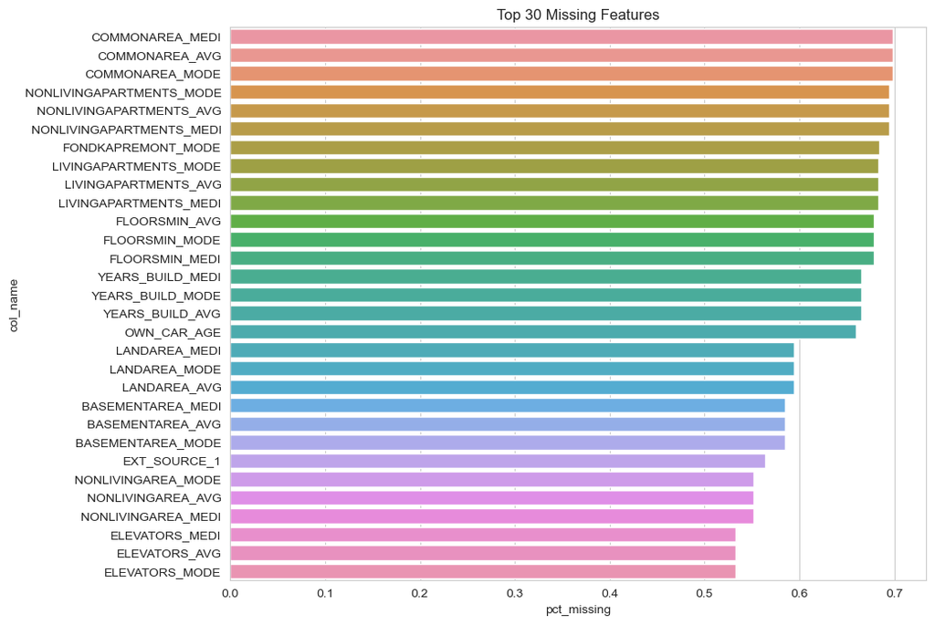

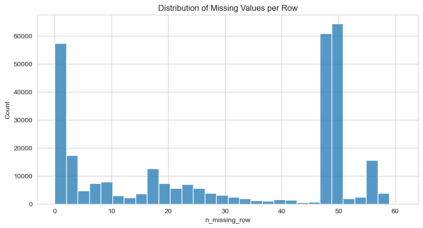

```
Saved table: tables/missingness_signals.csv
```

|  | feature | missing_rate | target_rate_missing | target_rate_present | lift |
| --- | --- | --- | --- | --- | --- |
| 15 | YEARS_BUILD_AVG | 0.664978 | 0.086807 | 0.068664 | 1.264206 |
| 14 | YEARS_BUILD_MODE | 0.664978 | 0.086807 | 0.068664 | 1.264206 |
| 13 | YEARS_BUILD_MEDI | 0.664978 | 0.086807 | 0.068664 | 1.264206 |
| 19 | LANDAREA_AVG | 0.593767 | 0.088198 | 0.069812 | 1.263338 |
| 18 | LANDAREA_MODE | 0.593767 | 0.088198 | 0.069812 | 1.263338 |
| 17 | LANDAREA_MEDI | 0.593767 | 0.088198 | 0.069812 | 1.263338 |
| 11 | FLOORSMIN_MODE | 0.678486 | 0.086311 | 0.068950 | 1.251769 |
| 12 | FLOORSMIN_MEDI | 0.678486 | 0.086311 | 0.068950 | 1.251769 |
| 10 | FLOORSMIN_AVG | 0.678486 | 0.086311 | 0.068950 | 1.251769 |
| 9 | LIVINGAPARTMENTS_MEDI | 0.683550 | 0.086214 | 0.068882 | 1.251602 |

```python
# Top Missing Columns
missing_ranking = df_schema.sort_values('pct_missing', ascending=False)
top_missing = missing_ranking[missing_ranking['pct_missing'] > 0].head(30)
display(top_missing[['col_name', 'pct_missing', 'n_missing']])

# Plot Top Missing
plt.figure(figsize=(10, 8))
sns.barplot(data=top_missing, y='col_name', x='pct_missing')
plt.title('Top 30 Missing Features')
save_figure(plt.gcf(), 'chapter_c_missing_top30.png')
plt.show()

# Row-wise Missing Count
df_train['n_missing_row'] = df_train.isnull().sum(axis=1)
plt.figure(figsize=(10, 5))
sns.histplot(df_train['n_missing_row'], bins=30)
plt.title('Distribution of Missing Values per Row')
save_figure(plt.gcf(), 'chapter_c_row_missingness.png')
plt.show()

# Missingness vs Target (Lift Analysis)
# Identify columns with meaningful missingness (> 5% missing)
high_missing_cols = missing_ranking[missing_ranking['pct_missing'] > 0.05]['col_name'].tolist()

missing_signals = []
for col in high_missing_cols[:20]: # Limit to top 20 to save time
    is_missing = df_train[col].isnull()
    target_rate_missing = df_train[is_missing][TARGET_COL].mean()
    target_rate_present = df_train[~is_missing][TARGET_COL].mean()

    missing_signals.append({
        'feature': col,
        'missing_rate': is_missing.mean(),
        'target_rate_missing': target_rate_missing,
        'target_rate_present': target_rate_present,
        'lift': target_rate_missing / (target_rate_present + 1e-6)
    })

df_missing_signals = pd.DataFrame(missing_signals).sort_values('lift', ascending=False)
save_table(df_missing_signals, 'missingness_signals.csv')
display(df_missing_signals.head(10))
```

## Chapter D: Numerical Features EDA

- **Goal**: Distribution, Statistics, and Target Relationship for numerical features.

```
Saved table: tables/numeric_summary.csv
```

|  | count | mean | std | min | 1% | 5% | 25% | 50% | 75% | 95% | 99% | max | missing% | skew | kurtosis |
| --- | --- | --- | --- | --- | --- | --- | --- | --- | --- | --- | --- | --- | --- | --- | --- |
| CNT_CHILDREN | 307511.0 | 0.417052 | 0.722121 | 0.0 | 0.00 | 0.0 | 0.0 | 0.0 | 1.0 | 2.0 | 3.0 | 19.0 | 0.000000 | 1.974604 | 7.904106 |
| AMT_INCOME_TOTAL | 307511.0 | 168797.919297 | 237123.146279 | 25650.0 | 45000.00 | 67500.0 | 112500.0 | 147150.0 | 202500.0 | 337500.0 | 472500.0 | 117000000.0 | 0.000000 | 391.559654 | 191786.554381 |
| AMT_CREDIT | 307511.0 | 599025.999706 | 402490.776996 | 45000.0 | 76410.00 | 135000.0 | 270000.0 | 513531.0 | 808650.0 | 1350000.0 | 1854000.0 | 4050000.0 | 0.000000 | 1.234778 | 1.934041 |
| AMT_ANNUITY | 307499.0 | 27108.573909 | 14493.737315 | 1615.5 | 6182.91 | 9000.0 | 16524.0 | 24903.0 | 34596.0 | 53325.0 | 70006.5 | 258025.5 | 0.000039 | 1.579777 | 7.707320 |
| AMT_GOODS_PRICE | 307233.0 | 538396.207429 | 369446.460540 | 40500.0 | 67500.00 | 135000.0 | 238500.0 | 450000.0 | 679500.0 | 1305000.0 | 1800000.0 | 4050000.0 | 0.000904 | 1.349000 | 2.431916 |

```
Saved table: tables/numeric_signal_ranking.csv
Top Numeric Signals by AUC:
```

|  | feature | auc | ks_stat |
| --- | --- | --- | --- |
| 25 | EXT_SOURCE_3 | 0.679400 | 0.269812 |
| 23 | EXT_SOURCE_1 | 0.665681 | 0.242696 |
| 24 | EXT_SOURCE_2 | 0.656120 | 0.223739 |
| 6 | OWN_CAR_AGE | 0.558884 | 0.102979 |
| 33 | FLOORSMAX_AVG | 0.550385 | 0.072471 |
| 61 | FLOORSMAX_MEDI | 0.550027 | 0.071479 |
| 15 | REGION_RATING_CLIENT_W_CITY | 0.549182 | 0.063987 |
| 47 | FLOORSMAX_MODE | 0.549098 | 0.068798 |
| 14 | REGION_RATING_CLIENT | 0.548063 | 0.064168 |
| 37 | LIVINGAREA_AVG | 0.547116 | 0.068652 |

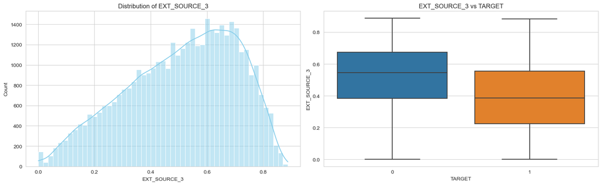

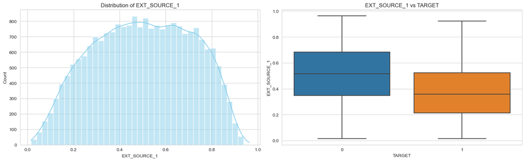

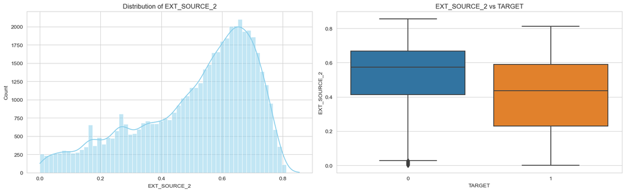

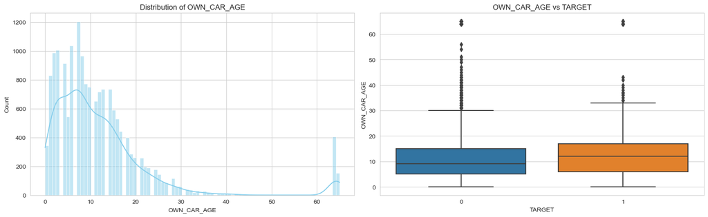

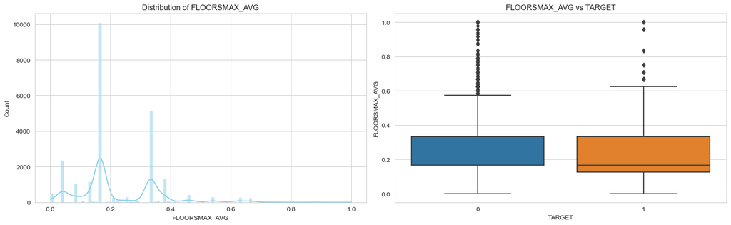

```python
# Identify Numerical Columns
numeric_cols = df_schema[df_schema['inferred_type'] == 'numeric']['col_name'].tolist()
# Exclude ID and Target
numeric_cols = [c for c in numeric_cols if c not in [ID_COL, TARGET_COL, 'n_missing_row']]

# D1. Numerical Summary
num_summary = df_train[numeric_cols].describe(percentiles=[0.01, 0.05, 0.25, 0.5, 0.75, 0.95, 0.99]).T
num_summary['missing%'] = df_train[numeric_cols].isnull().mean()
num_summary['skew'] = df_train[numeric_cols].skew()
num_summary['kurtosis'] = df_train[numeric_cols].kurtosis()
save_table(num_summary, 'numeric_summary.csv')
display(num_summary.head())

# D3. Numeric Signal Ranking (AUC/KS)
numeric_signals = []
for col in numeric_cols:
    # Drop NA for calculation
    valid_data = df_train[[col, TARGET_COL]].dropna()
    if len(valid_data) < 100 or valid_data[col].nunique() < 2:
        continue

    try:
        # Simple AUC (using feature as score)
        auc = roc_auc_score(valid_data[TARGET_COL], valid_data[col])
        # If AUC < 0.5, flip it (feature might be negatively correlated)
        auc = max(auc, 1-auc)

        # KS Statistic
        s0 = valid_data[valid_data[TARGET_COL]==0][col]
        s1 = valid_data[valid_data[TARGET_COL]==1][col]
        ks_stat, _ = stats.ks_2samp(s0, s1)

        numeric_signals.append({
            'feature': col,
            'auc': auc,
            'ks_stat': ks_stat
        })
    except Exception as e:
        pass

df_num_signals = pd.DataFrame(numeric_signals).sort_values('auc', ascending=False)
save_table(df_num_signals, 'numeric_signal_ranking.csv')
print("Top Numeric Signals by AUC:")
display(df_num_signals.head(10))

# Plot Top 5 Features
for col in df_num_signals['feature'].head(5):
    fig = plot_distribution(df_train, col)
    save_figure(fig, f'chapter_d_dist_{col}.png')
    plt.show()
```

## Chapter E: Categorical Features EDA

- **Goal**: Analyze categorical features, cardinality, and target rates.

```python
cat_cols = df_schema[df_schema['inferred_type'] == 'categorical']['col_name'].tolist()

# E1 & E2. Categorical Stats & Ranking
cat_stats = []

for col in cat_cols:
    total_count = len(df_train)
    n_unique = df_train[col].nunique()

    # Calculate Target Rate Variance (weighted) or Mutual Information (simple proxy)
    # Here we look at the range of target rates across categories

    # Group by category
    grp = df_train.groupby(col)[TARGET_COL].agg(['count', 'mean'])
    grp = grp.sort_values('count', ascending=False)

    # Check for rare classes (<1%)
    rare_mask = (grp['count'] / total_count) < 0.01
    n_rare = rare_mask.sum()
    pct_rare = grp[rare_mask]['count'].sum() / total_count

    # Signal strength: Range of target rates (max - min) for categories with meaningful size (>100 samples)
    valid_cats = grp[grp['count'] > 100]
    tr_range = 0
    if len(valid_cats) > 1:
        tr_range = valid_cats['mean'].max() - valid_cats['mean'].min()

    cat_stats.append({
        'feature': col,
        'n_unique': n_unique,
        'n_rare_cats': n_rare,
        'pct_rare_samples': pct_rare,
        'target_rate_range': tr_range
    })

    # Plot Top categories
    if n_unique <= 50: # Limit plots
        plt.figure(figsize=(12, 5))
        # Top 10 categories
        top_cats = grp.head(10).index
        plot_data = df_train[df_train[col].isin(top_cats)]

        sns.barplot(data=plot_data, x=col, y=TARGET_COL, order=top_cats, errorbar=('ci', 95))
        plt.title(f'{col} Default Rate (Top Categories)')
        plt.xticks(rotation=45)
        save_figure(plt.gcf(), f'chapter_e_{col}_target_rate.png')
        plt.close()

df_cat_stats = pd.DataFrame(cat_stats).sort_values('target_rate_range', ascending=False)
save_table(df_cat_stats, 'categorical_signal_ranking.csv')
display(df_cat_stats)
```

```
Saved table: tables/categorical_signal_ranking.csv
```

|  | feature | n_unique | n_rare_cats | pct_rare_samples | target_rate_range |
| --- | --- | --- | --- | --- | --- |
| 9 | OCCUPATION_TYPE | 18 | 7 | 0.030041 | 0.123221 |
| 11 | ORGANIZATION_TYPE | 58 | 41 | 0.135956 | 0.119600 |
| 6 | NAME_EDUCATION_TYPE | 5 | 1 | 0.000533 | 0.090984 |
| 8 | NAME_HOUSING_TYPE | 6 | 2 | 0.012159 | 0.057406 |
| 14 | WALLSMATERIAL_MODE | 7 | 3 | 0.018536 | 0.049761 |
| 5 | NAME_INCOME_TYPE | 8 | 4 | 0.000179 | 0.042021 |
| 7 | NAME_FAMILY_STATUS | 6 | 1 | 0.000007 | 0.041204 |
| 13 | HOUSETYPE_MODE | 3 | 2 | 0.008816 | 0.031967 |
| 1 | CODE_GENDER | 3 | 1 | 0.000013 | 0.031426 |
| 0 | NAME_CONTRACT_TYPE | 2 | 0 | 0.000000 | 0.028676 |
| 15 | EMERGENCYSTATE_MODE | 2 | 1 | 0.007570 | 0.026141 |
| 4 | NAME_TYPE_SUITE | 7 | 3 | 0.009453 | 0.024537 |
| 12 | FONDKAPREMONT_MODE | 4 | 0 | 0.000000 | 0.017240 |
| 2 | FLAG_OWN_CAR | 2 | 0 | 0.000000 | 0.012565 |
| 10 | WEEKDAY_APPR_PROCESS_START | 7 | 0 | 0.000000 | 0.005933 |
| 3 | FLAG_OWN_REALTY | 2 | 0 | 0.000000 | 0.003634 |

## Chapter F: Correlation & Redundancy

- **Goal**: Identify collinearity and strong correlations.

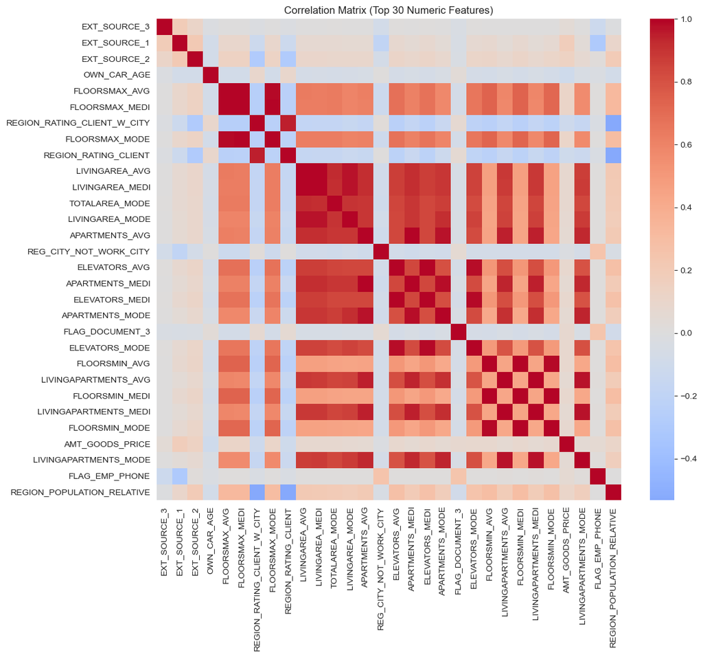

```
Saved table: tables/high_correlation_pairs.csv
```

|  | feat_a | feat_b | corr | abs_corr |
| --- | --- | --- | --- | --- |
| 400 | FLOORSMIN_AVG | FLOORSMIN_MEDI | 0.997241 | 0.997241 |
| 110 | FLOORSMAX_AVG | FLOORSMAX_MEDI | 0.997034 | 0.997034 |
| 331 | ELEVATORS_AVG | ELEVATORS_MEDI | 0.996099 | 0.996099 |
| 225 | LIVINGAREA_AVG | LIVINGAREA_MEDI | 0.995596 | 0.995596 |
| 301 | APARTMENTS_AVG | APARTMENTS_MEDI | 0.995081 | 0.995081 |
| 408 | LIVINGAPARTMENTS_AVG | LIVINGAPARTMENTS_MEDI | 0.993825 | 0.993825 |
| 415 | FLOORSMIN_MEDI | FLOORSMIN_MODE | 0.988406 | 0.988406 |
| 136 | FLOORSMAX_MEDI | FLOORSMAX_MODE | 0.988237 | 0.988237 |
| 402 | FLOORSMIN_AVG | FLOORSMIN_MODE | 0.985875 | 0.985875 |
| 112 | FLOORSMAX_AVG | FLOORSMAX_MODE | 0.985689 | 0.985689 |
| 359 | ELEVATORS_MEDI | ELEVATORS_MODE | 0.982828 | 0.982828 |
| 334 | ELEVATORS_AVG | ELEVATORS_MODE | 0.978837 | 0.978837 |
| 345 | APARTMENTS_MEDI | APARTMENTS_MODE | 0.977193 | 0.977193 |
| 422 | LIVINGAPARTMENTS_MEDI | LIVINGAPARTMENTS_MODE | 0.975605 | 0.975605 |
| 246 | LIVINGAREA_MEDI | LIVINGAREA_MODE | 0.974743 | 0.974743 |

```python
# Numerical Correlation (Top Features)
# Use top 30 numeric features by signal to avoid huge matrix
top_numeric = df_num_signals.head(30)['feature'].tolist()
corr_mat = df_train[top_numeric].corr()

plt.figure(figsize=(12, 10))
sns.heatmap(corr_mat, cmap='coolwarm', center=0, annot=False)
plt.title('Correlation Matrix (Top 30 Numeric Features)')
save_figure(plt.gcf(), 'chapter_f_corr_matrix.png')
plt.show()

# List strong pairs
corr_pairs = (corr_mat.where(np.triu(np.ones(corr_mat.shape), k=1).astype(bool))
              .stack()
              .to_frame('corr')
              .reset_index())
corr_pairs.columns = ['feat_a', 'feat_b', 'corr']
corr_pairs['abs_corr'] = corr_pairs['corr'].abs()
high_corr = corr_pairs[corr_pairs['abs_corr'] > 0.7].sort_values('abs_corr', ascending=False)
save_table(high_corr, 'high_correlation_pairs.csv')
display(high_corr.head(15))
```

## Chapter G: Outliers & Sentinel Values

- **Goal**: Scan for potential sentinel values (e.g. 365243 in DAYS columns) and extreme outliers.

```python
sentinel_candidates = []

for col in numeric_cols:
    # Check for specific value heavily repeated (Mode) that is at the edge
    mode_val = df_train[col].mode()[0]
    mode_count = (df_train[col] == mode_val).sum()
    mode_pct = mode_count / len(df_train)

    # Check if max or min is far from percentiles
    desc = num_summary.loc[col]

    is_suspicious = False
    note = ""

    # Case: Days Employed 365243
    if col == 'DAYS_EMPLOYED' and 365243 in df_train[col].values:
        is_suspicious = True
        note = "Known Sentinel: 365243"

    # Case: Mode distinct from median/mean and high pct
    if mode_pct > 0.05 and abs(mode_val - desc['50%']) > desc['std']:
        is_suspicious = True
        note += f" | High freq mode: {mode_val} ({mode_pct:.1%})"

    if is_suspicious:
        sentinel_candidates.append({
            'feature': col,
            'suspicious_value': mode_val,
            'count': mode_count,
            'pct': mode_pct,
            'notes': note
        })

df_sentinels = pd.DataFrame(sentinel_candidates)
save_table(df_sentinels, 'potential_sentinels.csv')
display(df_sentinels)

# Visualize Sentinel vs Target for DAYS_EMPLOYED if exists
if 'DAYS_EMPLOYED' in df_train.columns:
    df_train['is_365243'] = df_train['DAYS_EMPLOYED'] == 365243
    print(df_train.groupby('is_365243')[TARGET_COL].agg(['count', 'mean']))
```

```
Saved table: tables/potential_sentinels.csv
```

|  | feature | suspicious_value | count | pct | notes |
| --- | --- | --- | --- | --- | --- |
| 0 | REGION_POPULATION_RELATIVE | 0.035792 | 16408 | 0.053357 | \| High freq mode: 0.035792 (5.3%) |

```
            count      mean
is_365243
False      252137  0.086600
True        55374  0.053996
```

## Chapter H: Train vs Test Drift

- **Goal**: Compare distribution between Train and Test sets (if Test set exists).

```python
if os.path.exists(TEST_PATH):
    df_test = pd.read_csv(TEST_PATH)
    print(f"Loaded Test Data: {df_test.shape}")

    drift_results = []

    # Check Top Numeric Features for Drift using KS
    for col in top_numeric[:20]: # Check top signals
        if col in df_test.columns:
            s_train = df_train[col].dropna()
            s_test = df_test[col].dropna()

            ks_stat, p_val = stats.ks_2samp(s_train, s_test)
            drift_results.append({
                'feature': col,
                'metric': 'KS',
                'value': ks_stat,
                'drift_detected': ks_stat > 0.1 # Threshold
            })

    df_drift = pd.DataFrame(drift_results).sort_values('value', ascending=False)
    save_table(df_drift, 'drift_analysis.csv')
    display(df_drift.head())
else:
    print("Application Test file not found. Skipping Drift Analysis.")
```

```
Application Test file not found. Skipping Drift Analysis.
```

## Chapter I: Bias / Fairness EDA

- **Goal**: Explore default rates across sensitive attributes (Gender, Age).

```
Gender Analysis:
```

| CODE_GENDER | count | mean |
| --- | --- | --- |
| F | 202448 | 0.069993 |
| M | 105059 | 0.101419 |
| XNA | 4 | 0.000000 |

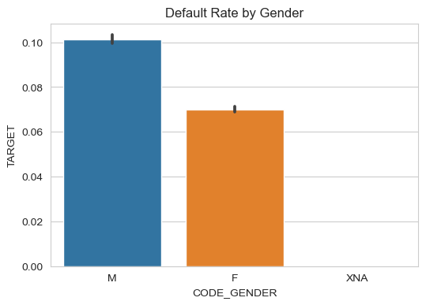

```
Age Analysis:
```

| AGE_BIN | count | mean |
| --- | --- | --- |
| (20, 30] | 45021 | 0.114569 |
| (30, 40] | 82308 | 0.095835 |
| (40, 50] | 76541 | 0.076508 |
| (50, 60] | 68062 | 0.061297 |
| (60, 70] | 35579 | 0.049214 |
| (70, 100] | 0 | NaN |

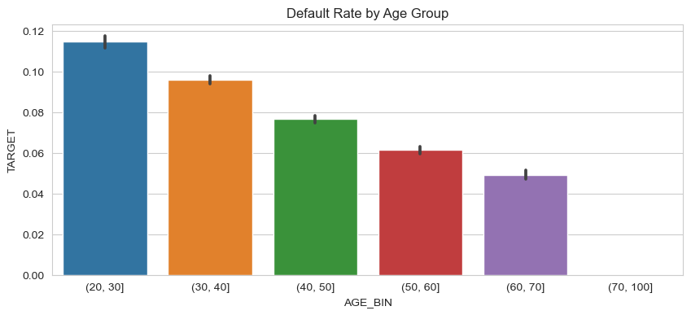

```python
# 1. Gender
if 'CODE_GENDER' in df_train.columns:
    print("Gender Analysis:")
    g_grp = df_train.groupby('CODE_GENDER')[TARGET_COL].agg(['count', 'mean'])
    display(g_grp)

    plt.figure(figsize=(6, 4))
    sns.barplot(data=df_train, x='CODE_GENDER', y=TARGET_COL, errorbar=('ci', 95))
    plt.title('Default Rate by Gender')
    save_figure(plt.gcf(), 'chapter_i_gender_bias.png')
    plt.show()

# 2. Age (Binning DAYS_BIRTH)
if 'DAYS_BIRTH' in df_train.columns:
    df_train['AGE'] = df_train['DAYS_BIRTH'] / -365
    df_train['AGE_BIN'] = pd.cut(df_train['AGE'], bins=[20, 30, 40, 50, 60, 70, 100])

    print("Age Analysis:")
    age_grp = df_train.groupby('AGE_BIN')[TARGET_COL].agg(['count', 'mean'])
    display(age_grp)

    plt.figure(figsize=(10, 4))
    sns.barplot(data=df_train, x='AGE_BIN', y=TARGET_COL, errorbar=('ci', 95))
    plt.title('Default Rate by Age Group')
    save_figure(plt.gcf(), 'chapter_i_age_bias.png')
    plt.show()
```

## Executive Summary & Outputs

The analysis is complete. Key tables have been saved to the `tables/` directory and figures to `figures/`. summary.json will be generated now.

```python
summary_json = {
    "n_rows": int(len(df_train)),
    "n_cols": int(len(df_train.columns)),
    "target_prevalence": float(prevalence),
    "top_missing_cols": top_missing['col_name'].tolist()[:5],
    "top_numeric_signals": df_num_signals['feature'].tolist()[:5] if 'df_num_signals' in locals() else [],
    "top_categorical_signals": df_cat_stats['feature'].tolist()[:5] if 'df_cat_stats' in locals() else []
}

with open('summary.json', 'w') as f:
    json.dump(summary_json, f, indent=4)

print("Summary JSON saved.")
print("To generate HTML report, try using: jupyter nbconvert --to html eda_report.ipynb")
```

```
Summary JSON saved.
To generate HTML report, try using: jupyter nbconvert --to html eda_report.ipynb
```